# Spatial Analytics Exam

# Join spatial and mayoral data

Now, we’re ready to join the spatial data with the mayoral data.

There’s some disrepancies between the expected number of municipalities and the one in the data. This is due to wrong encoding in the data. In the data Christiansø is encoded as a municipality, though this is not the case, so we exclude it.

Ærø municipality was established in 2006 by merging Ærøskøbing and Marstal. So, we exclude these two an keep only Ærø.

```r
## 2006

### join the sf object with the mayors dataframe
df_2006 <- full_join(denmark_2006, mayors_2006, join_by("navn" == "Kommunenavn"))

### remove: Ærø municipality - Christansø, not a municipality
df_2006 <- subset(df_2006, !(navn %in% c("Marstal", "Ærøskøbing", "Christiansø")))



## 2007
### join the sf object with the mayors dataframe
df_2007 <- full_join(denmark_2007, mayors_2007, join_by("navn" == "Kommunenavn"))

### christiansø is not a municipality
df_2007 <- subset(df_2007, navn!="Christiansø")
```

# Visualize using tmap

We visualize the distribution of mayoral posts between the blocs using “tmap”.

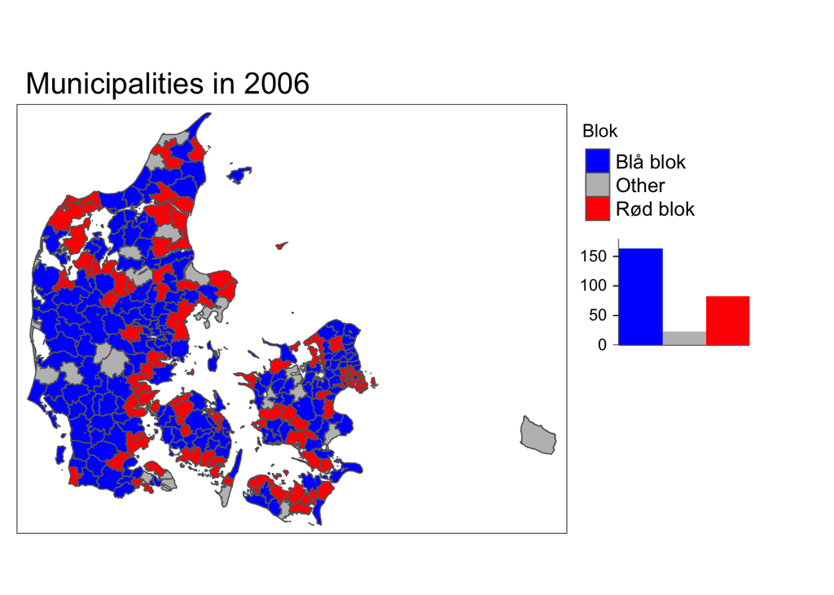

```r
## 2006

p2006 <- df_2006 %>%
  tm_shape() +
  tm_polygons("Blok",
              palette = c("Rød blok" = "red", "Blå blok" = "blue", "Other" = "grey"),
              legend.hist = TRUE) +
  tm_layout(main.title = "Municipalities in 2006",
            main.title.size = 1.5,
             frame = TRUE,
             legend.outside = TRUE,
             legend.text.size = 1,
             legend.hist.size = 1,
             legend.hist.width = 0.75)

p2006
```

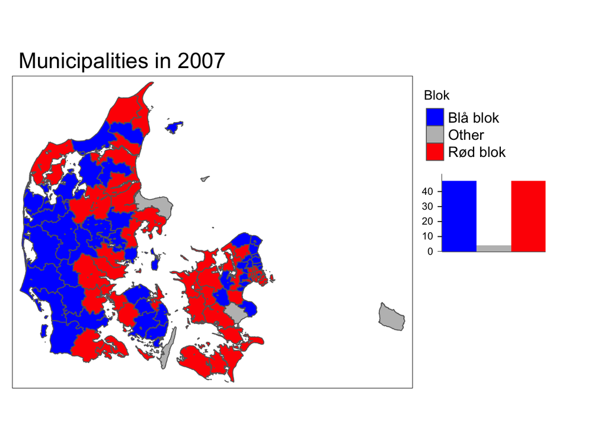

```r
## 2007

p2007 <- df_2007 %>%
  tm_shape() +
  tm_polygons("Blok",
              palette = c("Rød blok" = "red", "Blå blok" = "blue", "Other" = "grey"),
              legend.hist = TRUE) +
  tm_layout(main.title = "Municipalities in 2007",
            main.title.size = 1.5,
             frame = TRUE,
             legend.outside = TRUE,
             legend.text.size = 1,
             legend.hist.size = 1,
             legend.hist.width = 0.75)
p2007
```

```r
# save the plot
pdf('out/municipalities.pdf')
tmap_arrange(p2006, p2007,   outer.margins = 0.02)
dev.off()
```

# Tabel

We quantify the number of municipalities with a blue vs red mayor in 2006 by summarizing the visualized distribution and calculating the percentages.

```r
# Find the total population for each block
total_municipalities_2006 <- nrow(df_2006)

block_2006 <- df_2006 %>%
  group_by(Blok) %>%
  summarize(municipality_count = n(),
            percentage = round(municipality_count/total_municipalities_2006*100))
block_2006
```

```
## Simple feature collection with 3 features and 3 fields
## Geometry type: MULTIPOLYGON
## Dimension:     XY
## Bounding box:  xmin: 441571 ymin: 6049784 xmax: 892722.3 ymax: 6402201
## Projected CRS: ETRS89 / UTM zone 32N
## # A tibble: 3 × 4
##   Blok     municipality_count percentage                                geometry
##   <chr>                 <int>      <dbl>                      <MULTIPOLYGON [m]>
## 1 Blå blok                163         60 (((465031.9 6138464, 465030.4 6138444,…
## 2 Other                    24          9 (((559737.2 6079176, 559734 6079171, 5…
## 3 Rød blok                 84         31 (((481827.8 6083395, 481390.5 6083577,…
```

# Population

Untill now only looked at number of regions ruled over. To better quantify the “power”, we include number of citizens ruled over and generate a barplot displaying the top 30 biggest municipalities with the color of their mayor in 2007.

I couldn’t access data from pre-reform, so this will only display the distribution after.

```r
# Incorporate size of the "municipality"
## Find the total population for each block
total_municipalities_2007 <- nrow(df_2007)

block_population <- df_2007 %>%
  group_by(Blok) %>%
  summarize(total_population = sum(indbyggertal, na.rm = TRUE),
            municipality_count = n(),
            percentage = round(municipality_count/total_municipalities_2007*100))

block_population
```

```
## Simple feature collection with 3 features and 4 fields
## Geometry type: MULTIPOLYGON
## Dimension:     XY
## Bounding box:  xmin: 441571 ymin: 6049784 xmax: 892722.3 ymax: 6402201
## Projected CRS: ETRS89 / UTM zone 32N
## # A tibble: 3 × 5
##   Blok  total_population municipality_count percentage                  geometry
##   <chr>            <dbl>              <int>      <dbl>        <MULTIPOLYGON [m]>
## 1 Blå …          2115869                 47         48 (((454218.2 6154302, 454…
## 2 Other           130427                  4          4 (((606903 6072962, 60690…
## 3 Rød …          3200693                 47         48 (((509808.6 6080476, 509…
```

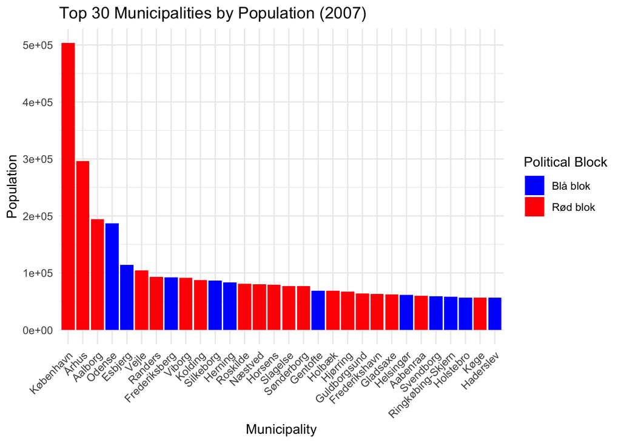

```r
# Find the top 30 municipalities by population
top_30_municipalities <- df_2007 %>%
  arrange(desc(indbyggertal)) %>%
  slice_head(n = 30)


# Create the bar plot for the top 30 municipalities by population

top30 <- ggplot(top_30_municipalities, aes(x = reorder(navn, -indbyggertal), y = indbyggertal, fill = Blok)) +
  geom_bar(stat = "identity") +
  scale_fill_manual(values = c("Rød blok" = "red", "Blå blok" = "blue", "Other" = "grey")) +
  labs(title = "Top 30 Municipalities by Population (2007)", x = "Municipality", y = "Population", fill = "Political Block") +
  theme_minimal() +
  theme(axis.text.x = element_text(angle = 45, hjust = 1))

top30
```

```r
pdf('out/30_biggest_municipalities.pdf')
top30
dev.off()
```

# Cartogram

The difference between the municipality size based on population vs area is visualized using a cartogram that controls for the visual weight carried by the bigger municipalities with a low density population, while still protecting the location.

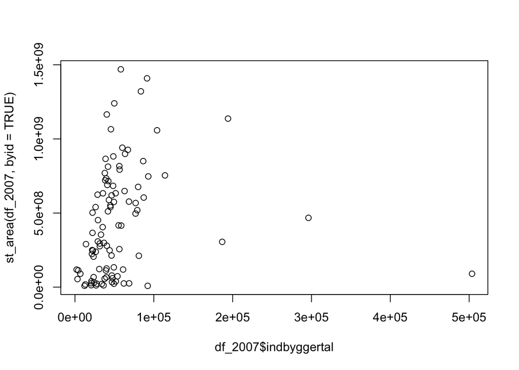

```r
# Make a cartogram, scaling the area to the total number people in 2007
cart_2007 <- cartogram_cont(df_2007, "indbyggertal")

# Now check the linearity of the total voters per municipality cartogram as opposed to the reality
plot(df_2007$indbyggertal, st_area(df_2007 , byid = TRUE)) # reality
```

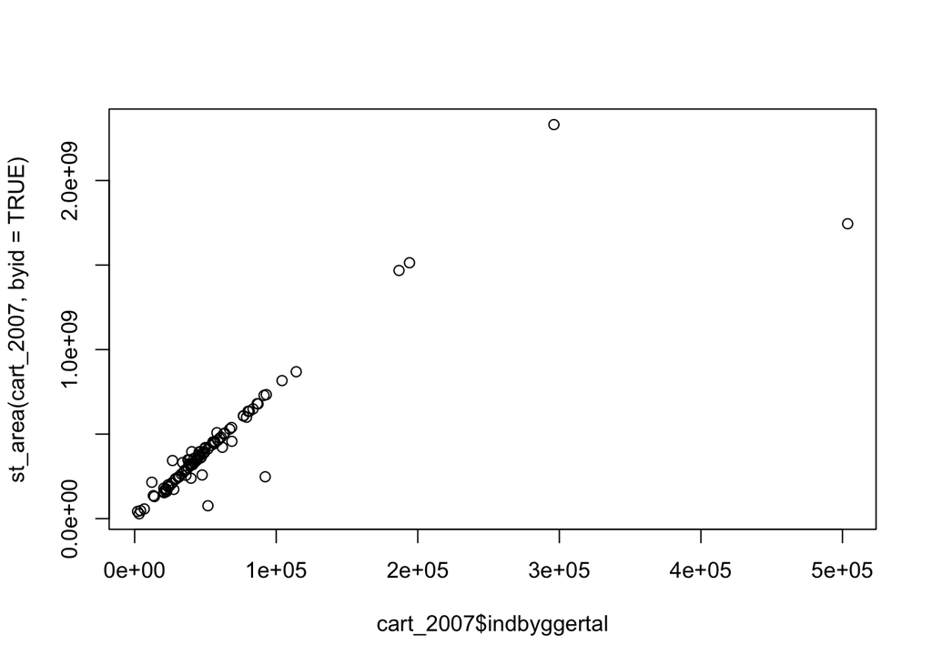

```r
plot(cart_2007$indbyggertal, st_area(cart_2007, byid = TRUE)) # cartogram
```

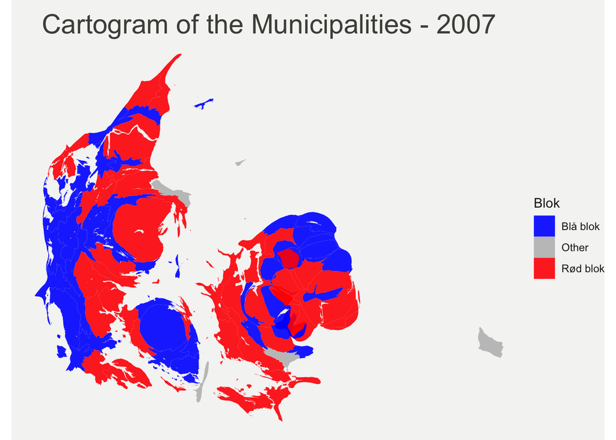

```r
cartogram <- ggplot(cart_2007) +
  geom_sf(aes(fill = Blok), linewidth = 0, alpha = 0.9) +
  theme_void() +
  scale_fill_manual(values = c("Rød blok" = "red", "Blå blok" = "blue", "Other" = "grey"))+
      labs(title = "Cartogram of the Municipalities - 2007") +
  theme(
    text = element_text(color = "#22211d"),
    plot.background = element_rect(fill = "#f5f5f4", color = NA),
    panel.background = element_rect(fill = "#f5f5f4", color = NA),
    legend.background = element_rect(fill = "#f5f5f4", color = NA),
    plot.title = element_text(
      size = 22, hjust = 0.5,
      color = "#4e4d47",
      margin = margin(
        b = -0.1, t = 0.4, l = 2,
        unit = "cm")))
cartogram
```

```r
pdf('out/cartogram.pdf')
cartogram
dev.off()
```

The findings do not support our hypothesis. On the contrary the red bloc seem to have benefitted more from the restructuring, suggesting that gerrymandering was not a part in how the restructuring was performed.

# Morans I

To inspire further research a quick analysis of spatial autocorrelation with Morans I is done. The number of old municipalities was 270, that formed into 98. This means that the new municipalities on average consists of `270/98 = 2,75` old. So each municipality would have to merge with two. Therefore, I run a k-nearest neighbors with k = 2 to check for spatial autocorrelation.

Preferably a further study should include severel ways to define neighbors: Contiguity-Based, either with the rook criterion for municipalities that share a common edge, or queen adjacency for when they share a border.

I run a Monte-Carlo simulation of Moran I to get a more robust result.

```r
# Check class and validity of dfs
class(df_2006)
```

```
## [1] "sf"         "data.frame"
```

```r
class(df_2007)
```

```
## [1] "sf"         "data.frame"
```

```r
length(st_is_valid(df_2006))
```

```
## [1] 271
```

```r
length(st_is_valid(df_2007))
```

```
## [1] 98
```

```r
# Check for empty geometries
empty_geoms <- df_2006[st_is_empty(df_2006), ]
empty_geoms <- df_2006[st_is_empty(df_2007), ]

# Remove rows with empty geometries
df_2006 <- df_2006[!st_is_empty(df_2006), ]
df_2007 <- df_2007[!st_is_empty(df_2007), ]

# make blok numeric!
df_2006$Blok <- as.numeric(as.factor(df_2006$Blok))
df_2007$Blok <- as.numeric(as.factor(df_2007$Blok))


# Make neighbor list from 2 nearest neighbours
## add a point to be the center
mun_centers <- st_coordinates(st_centroid(df_2006$geometry))
nb_k2 <- knn2nb(knearneigh(mun_centers, k = 2))

mun_centers_07 <- st_coordinates(st_centroid(df_2007$geometry))
nb_k2_07 <- knn2nb(knearneigh(mun_centers_07, k = 2))

pdf('out/nn_2006.pdf')
plot(df_2006$geometry); plot(nb_k2, mun_centers, col = "red",add = TRUE)
title(main="Pre-reform (2006) - 2 nearest neighbours")
dev.off()
```

```r
pdf('out/nn_2007.pdf')
plot(df_2007$geometry); plot(nb_k2_07, mun_centers_07, col = "red",add = TRUE)
title(main="Post-reform (2007) - 2 nearest neighbours")
dev.off()
```

```r
# Spatial autocorrelation analysis
moran_2006 <- moran.test(df_2006$Blok,
           nb2listw(nb_k2, style = "W",zero.policy=TRUE),
           zero.policy=TRUE)


moran_2007 <- moran.test(df_2007$Blok,
           nb2listw(nb_k2_07, style = "W", zero.policy=TRUE),
           zero.policy=TRUE)

# Print Moran's I statistics
print(moran_2006)
```

```
##
##  Moran I test under randomisation
##
## data:  df_2006$Blok
## weights: nb2listw(nb_k2, style = "W", zero.policy = TRUE)
##
## Moran I statistic standard deviate = 1.0246, p-value = 0.1528
## alternative hypothesis: greater
## sample estimates:
## Moran I statistic       Expectation          Variance
##       0.053844481      -0.003731343       0.003157461
```

```r
print(moran_2007)
```

```
##
##  Moran I test under randomisation
##
## data:  df_2007$Blok
## weights: nb2listw(nb_k2_07, style = "W", zero.policy = TRUE)
##
## Moran I statistic standard deviate = 1.5673, p-value = 0.05852
## alternative hypothesis: greater
## sample estimates:
## Moran I statistic       Expectation          Variance
##       0.132978723      -0.010309278       0.008357771
```

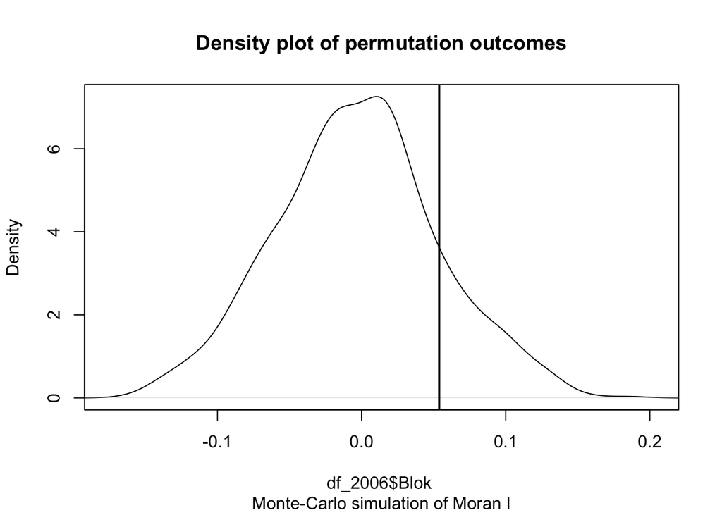

```r
# run monte carlo simulation for a more robust output.

mc06 <- moran.mc(df_2006$Blok,
         nb2listw(nb_k2, zero.policy=TRUE),
         zero.policy=TRUE, nsim = 999)

mc07 <- moran.mc(df_2007$Blok,
         nb2listw(nb_k2_07, zero.policy=TRUE),
         zero.policy=TRUE, nsim = 999)


plot(mc06)
```

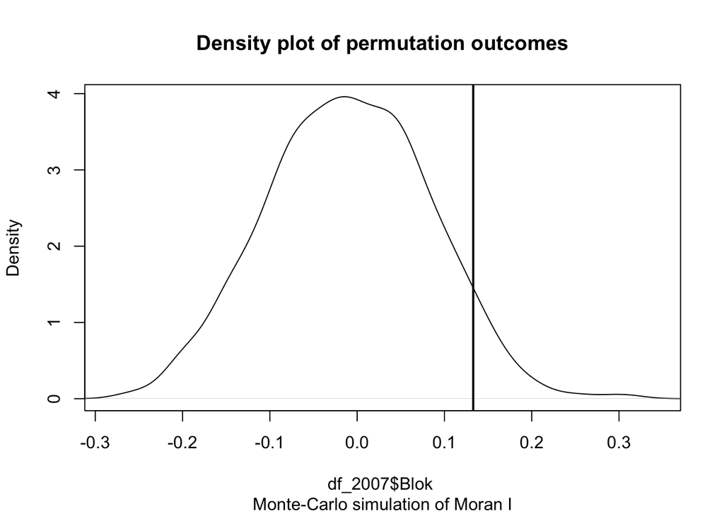

```r
plot(mc07)
```

Though there’s no significant spatial correlation, the Morans statistic is bigger after reform suggesting more geographical clustering for the mayoral distribution. The reason for this could pose an interesting question for further research. One interesting approach could also be to model the association between the neighbor lists from the 2006 municipalities and the outcome of the reform. How alike are they?

# Conclusion

It’s evident that the blue bloc did not benefit from the reform in terms of mayoral posts. Instead their percentage of mayoral post decreased from 60 % to 48 % with the red bloc having a 50 % larger amount of citizens under their “local wing”.  
This does not suggest any gerrymandering from the blue bloc. It’s recommended to further look into possible factors defining hoe the restructuring is done and which municipalities that merge with which. It’s suggested that spatial correlation could be a big factor.